# Data Science e Modello Hofstede

Alessio Stefan  
28/04/2021

### Descrizione MODELLO HOSTEDE

[figure not shown]

Per informazioni piu dettagliate visitare il [sito ufficiale](https://www.hofstede-insights.com/)

[figure not shown]

Hofstede divide ogni cultura in 6 dimensioni distinte ed indipendenti che hanno un valore da un minimo di 0 ad un massimo di 100

In questo progetto affiancheremo queste dimensioni ad altri dati e studiarne, se presenti, le relazioni che questi hanno

### Dataframe di partenza

(questo e' il dataframe (raw) per quanto riguarda gli studi di hofstede non quello di studio finale)

```
                 Country PD_INDEX INV_INDEX M_INDEX UA_INDEX LTO_INDEX
1             Bangladesh       80        20      55       60        47
2                 Bhutan       94        52      32       28        NA
3                  China       80        20      66       30        87
4                  India       77        48      56       40        51
5              Indonesia       78        14      46       48        62
6                   Iran       58        41      43       59        14
7                  Japan       54        46      95       92        88
8               Malaysia      100        26      50       36        41
9                  Nepal       65        30      40       40        NA
10              Pakistan       55        14      50       70        50
11           Philippines       94        32      64       44        27
12             Singapore       74        20      48        8        72
13             Sri Lanka       80        35      10       45        45
14                Taiwan       58        17      45       69        93
```

[output cut: 627 more lines]

### Caso 1) Relazione INDIVIDUALISMO-GDP

Tramite il calcolo con R trovando i coefficenti di corellazione verifichiamo una prima relazione

[figure not shown]

Per definizione l'individualismo e' quella dimensione dove ad alto livello viene data importanza sul **SINGOLO** individuo  
Mentre nel basso livello il **GRUPPO** viene visto come un'entita' piu' importante del singolo che ne fa parte  
Tramite questa definizione la domanda che spontaneamente ci si porge e' :  
la dimensione INDIVIDUALISMO puo' essere uno dei fattori che va ad influire sul **GDP**?

### 1.1) Visualizzazione dati e calcolo coefficente di corellazione

[interactive chart not shown]

Tramite il calcolo del **coefficente di corellazione**

```
[1] 0.6865381
```

Il che conferma una corellazione tra la dimensione **INDIVIDUALISMO** e **GDP**

### Caso 2) LO_INDEX influenza la scelta sui settori lavorativi

[figure not shown]

La dimensione Long Term Orientation valuta come una singola cultura si approccia al **FUTURO**.  
Avendo per ogni stato il valore LO_INDEX e 3 indici per valutare la “quantita'” di settore Primario (A),Secondario (I) e terziario (S) andiamo a valutare se al variare di LO_INDEX l'andamento dei 3 settori cambia ed in che modo

### 2.1) VISUALIZZAZIONE DATI

[interactive chart not shown]

### 2.2) OSSERVAZIONI e CALCOLO COEFFICENTI

Dalle osservazioni ottenute dal grafico precedente possiamo ipotizzare che esista un cambiamento nella frequenza dei settori lavorativi in base al valore di **LTO_INDEX**  
Per dimostrare l'ipotesi appena creata e capire il tipo di relazioni che legano LTO_INDEX con i 3 settori lavorativi

[figure not shown]

### 2.3) CONCLUSIONI

Riassumendo cio' che abbiamo osservato :

- La dimensione LTO ha una **corellazione** con Agricultura e Servizi ma non (direttamente) con l'Industria
- + LTO = **-** Agricultura
- + LTO = **+** Servizi
- - SERVIZI = **-** Industria (e **-**Agricultura)

  **Conclusioni**
  - Gli stati con un **alto LTO_INDEX** hanno una specializzazione nel settore terziario (a discapito del secondario e **primario**)
  - Gli stati con un **basso LTO_INDEX** hanno una frequenza minore nel settore terziario (aumentando di conseguenza secondario e primario)

### 2.3) CONCLUSIONI(PT.2)

```
          Country LTO_INDEX Agriculture Industry Service
1          Taiwan        93         1.8     25.9    72.3
2           Japan        88         1.7     25.8    72.5
3           China        87        12.5     47.3    40.3
4         Ukraine        86        18.7     45.2    36.1
5      Kazakhstan        85         6.7     38.6    54.7
6         Germany        83         0.9     29.6    69.5
7         Estonia        82         4.0     29.4    66.6
8       Lithuania        82         5.5     32.5    62.0
9         Belgium        82         1.0     24.0    74.9
10        Belarus        81         9.3     31.6    59.1
11         Russia        81         5.4     37.1    57.5
12       Slovakia        77         3.5     29.4    67.2
13    Switzerland        74         1.5     34.0    64.5
14      Singapore        72         0.0     33.9    66.1
15        Moldova        71        21.3     23.3    55.5
16 Czech Republic        70         3.4     39.3    57.3
17         Latvia        69         4.0     26.1    69.9
18       Bulgaria        69         9.3     30.4    60.3
19    Netherlands        67         2.1     24.4    73.6
20     Luxembourg        64         1.0     13.0    86.0
```

### 3) Cultura e flussi migratori

I fenomeni immigrazione ed emigrazione sono quantificati dal **NET-MIGRATION**

[figure not shown]

Controlliamo se c'e' una corellazione tra il **NET-MIGRATION** e 1 (o +) **dimensioni culturali**  
(Anche con GDP)

### 3.1) Visualizzazione grafico COEFFIECENTI

Ecco il **risultato** della ricerca dei coefficenti :

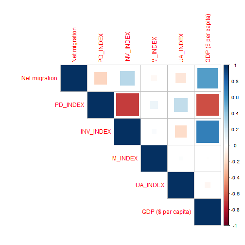

- Net Migration - GDP (+)
- Net Migration - PD (-)
- Net Migration - INV (+)
- PD - INV (-)
- PD - GDP (-)
- INV - GDP (+)

### 3.2.1) VISUALIZZAZIONE

**+ PD = - GDP**

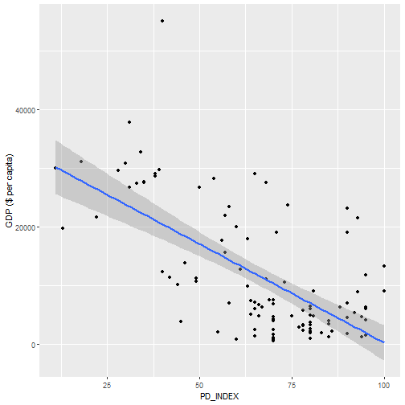

```
[1] -0.6448758
```

**- INV = - GDP** (grafico caso 1)

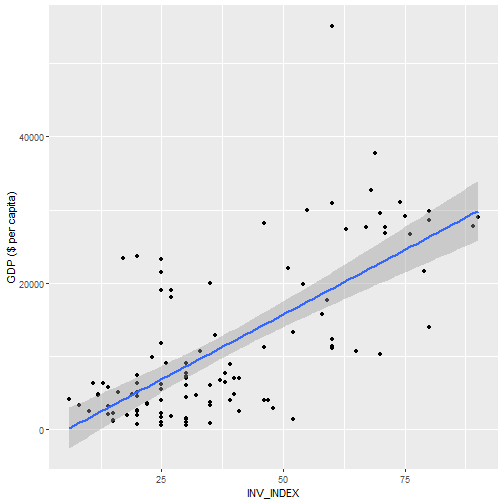

```
[1] 0.6865381
```

### 3.2.2) VISUALIZZAZIONE

**+ PD = - INV**

[interactive chart not shown]

```
[1] -0.6995731
```

Con i risultati ottenuti possiamo concludere  
**+ PD = - INV = - GDP = - NET**

### 3.2.3) VISUALIZZAZIONE

**- GDP = - NET MIGRATION**

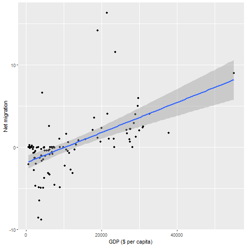

```
[1] 0.553884
```

**- INV = - NET MIGRATION**

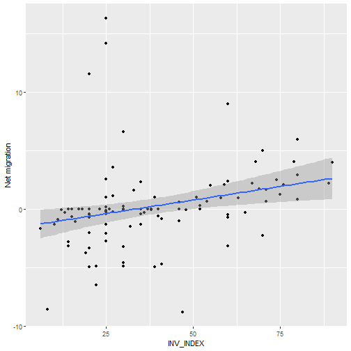

```
[1] 0.2729839
```

### 3.3) CONCLUSIONI

Gli stati (e regioni) con un tasso di **emigrazioni** alto hanno le seguenti caratteristiche:

- Alto PD
- Basso INV

```
     Country Net migration PD_INDEX INV_INDEX
1   Suriname         -8.81       85        47
2    Ecuador         -8.58       78         8
3    Armenia         -6.47       85        22
4    Albania         -4.93       90        20
5    Jamaica         -4.92       45        39
6 Azerbaijan         -4.90       85        22
7     Mexico         -4.87       81        30
8    Georgia         -4.70       65        41
```

```
# A tibble: 8 x 4
  Region                  Net    PD   INV
  <chr>                 <dbl> <dbl> <dbl>
1 LATIN AMER. & CARIB  -2.29   71.8  23.1
2 C.W. OF IND. STATES  -2.06   86.6  27.6
3 BALTICS              -2.03   42    63.3
4 EASTERN EUROPE       -0.663  75.1  41.5
5 NORTHERN AFRICA      -0.432  74    36.8
6 SUB-SAHARAN AFRICA   -0.202  70.9  26.8
7 ASIA (EX. NEAR EAST)  0.217  73.8  28.4
8 OCEANIA               1.63   46    61
```

### FINE

Tramite questo breve studio abbiamo utilizzato la Teoria di Hofstede dimostrando :

- Le **dimensioni di Hofstede** (e i diversi valori che hanno) e **valori “oggettivi”** hanno relazioni tra di loro
- Tramite gli indici si riesce ad **elaborare,visualizzare e comparare** i dati
- Le dimensioni da sole possono non essere sufficenti per determinati casi di studio
- Nel dominio della **gestione cross-culturale lavorativa**, le dimensioni possono avere rilevanza su delle scelte interne (ad esempio) in un'azienda